# Chapter2

5. Here are three diagnostics plots of this regression.

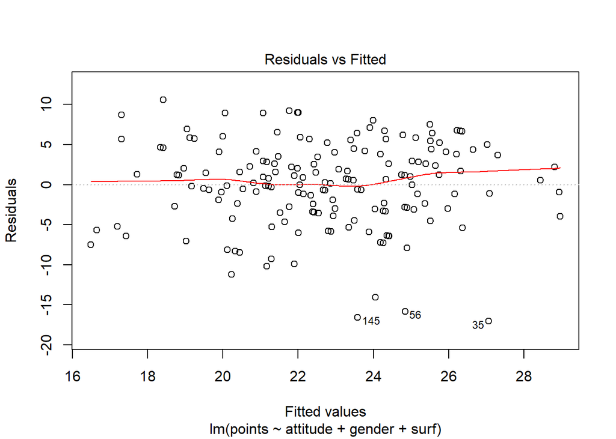

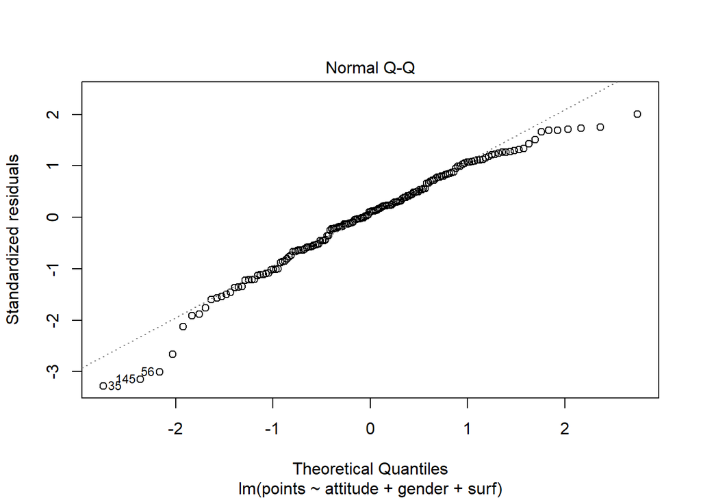

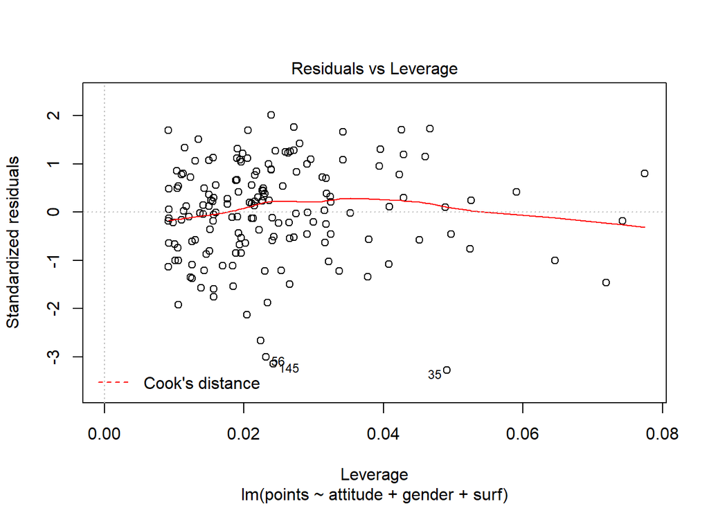

```r
plot(my_model, which=c(1,2,5))
```

The residuals vs. fitted plot speaks for the validity of the regression. In a reliable regression the points should be scatterered randomly and the line in the center about straight from right to left. This is roughly the case here.

Normal Q-Q plot looks also very good. Some extreme values are a bit of the line though.

Residuals vs. leverage tells which observations are not only extreme outliers but also significant. In this case there are not a lot points in far right corners so also this plot suggests that the regression is reliable.